# Test python installation

This is just a test lab. We strongly encourage you to run it. Most of it should work with no errors (but you may get warnings if you are using quite a different versions of the libraries).

## import libraries

We'll be using many libraries, here we import some of the more common ones.

```python
# !pip install tensorflow
```

```python
import pandas as pd
import numpy as np
import matplotlib
import matplotlib.pyplot as plt
import sklearn
from sklearn.neighbors import KNeighborsClassifier
import sys
```

Which versions of programs are we using?

```python
print("Python:", sys.version)
print("pandas:", pd.__version__)
print("numpy:", np.__version__)
print("matplotlib:", matplotlib.__version__)
print("sklearn:", sklearn.__version__)
```

```
Python: 3.9.7 | packaged by conda-forge | (default, Sep 29 2021, 19:20:46)
[GCC 9.4.0]
pandas: 1.3.4
numpy: 1.20.3
matplotlib: 3.4.3
sklearn: 1.0.1
```

## First test numpy and matplotlib plotting

You should see a histogram

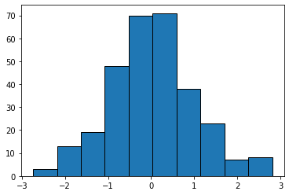

```python
N = 300
x = np.random.normal(size=N)
_ = plt.hist(x, edgecolor="k")
```

## Do we have working pandas?

Pandas is the python data frame library, and we need data frames!

You should see a tiny data frame with two variables, x and y, and their scatterplot where you see the variables are clearly correlated.

```
          x         y
0  2.067325  1.631323
1  0.078085  1.037924
2  0.536713  1.974123
3 -1.674898 -2.656618
4 -2.139106 -3.106806
```

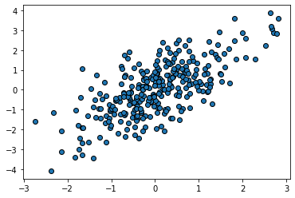

```python
df = pd.DataFrame( {'x':x, 'y': x + np.random.normal(size=N)})
print(df.head())
a = plt.scatter(df.x, df.y, edgecolor='k')
```

## Does sklearn work?

*sklearn* is one of the favorite predictive modeling libraries. Does it work? Let's try a decision boundary plot with nearest neighbors method

You should see a yellow/purple figure with yellow and purple dots. (This is 1-nearest-neighbors' decision boundary plot)

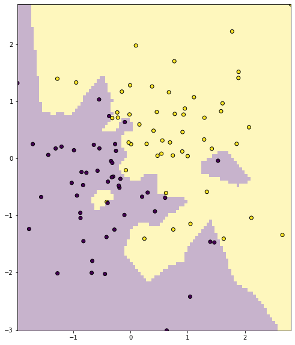

```python
N = 100
X1 = np.random.normal(size=N)
X2 = np.random.normal(size=N)
Y = X1 + X2 + np.random.normal(size=N) > 0
X = np.stack((X1, X2), axis=1)
m = KNeighborsClassifier(n_neighbors=1).fit(X, Y)
## Now greate the regular grid
ex1 = np.linspace(X1.min(), X1.max(), 100)
ex2 = np.linspace(X2.min(), X2.max(), 100)
xx1, xx2 = np.meshgrid(ex1, ex2)
                           # unlike R-s 'expand.grid', meshgrid creates matrices
g = np.stack((xx1.ravel(), xx2.ravel()), axis=1)
                           # we create the design matrix by stacking the xx1, xx2
                           # after unraveling those into columns
## predict on the grid
hatY = m.predict(g).reshape(100,100)
                           # imshow wants a matrix, so we reshape the predicted
                           # vector into one
plt.figure(figsize=(10,10))
ax = plt.subplot(1,1,1)
ax.set_aspect('equal')
ax.imshow(hatY, extent=(X1.min(), X1.max(), X2.min(), X2.max()),
           interpolation='none', origin='lower',
                           # you need to specify that the image begins from below,
                           # not above, otherwise it will be flipped around
           alpha=0.3)
ax.scatter(X1, X2, c=Y, edgecolor='k')
plt.show()
```

## Tensorflow

*tensorflow* is one of the state-of-the-art neural network libraries. This requires a working installation of tensorflow, and this may be quite a requirement. We will use it a little bit at the end of the course. If the following fails, no worries.

*tensorflow* works on the jupyterhub server, but you have to install it. You can do it in different ways, e.g. open terminal and issue command

```
pip install tensorflow
```

In your own computer we recommend to install it in a separate virtual environment, such as anaconda environment.

In the following we import tensorflow and do a simple neural network task with *keras*, *tensorflow*'s popular frontend. If tensorflow is correctly installed, it should work, but you may see warnings regarding missing CUDA (i.e. missing gpu). This is fine.

```python
import tensorflow as tf
print("tensorflow:", tf.__version__)
from tensorflow.keras.models import Sequential
from tensorflow.keras.layers import Dropout, Dense, BatchNormalization
from tensorflow.keras.callbacks import EarlyStopping, ReduceLROnPlateau
from tensorflow.keras.utils import to_categorical
from sklearn.model_selection import train_test_split
```

```
tensorflow: 2.8.0
```

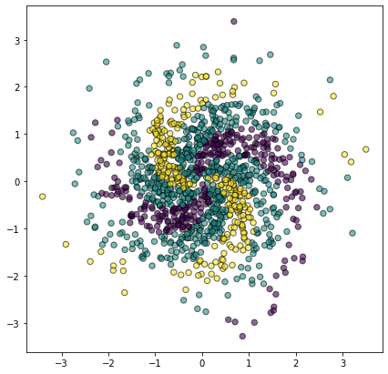

```python
n = 1200  # how many points
x1 = np.random.normal(size=n)
x2 = np.random.normal(size=n)
alpha = np.arctan2(x2, x1)
r = np.sqrt(x1**2 + x2**2)
c1 = (np.sin(2*alpha + 2*r) > 0).astype('int')
c2 = (np.cos(2*alpha + 2*r) > 0).astype('int')
c = c1 + c2  # this is your target
# features, target:
X = np.column_stack((x1,x2))
y = c
# this is how the data looks like:
plt.figure(figsize=(7,7))
plt.scatter(x1, x2, c=c, s=40, edgecolors='k', alpha=0.6)
plt.show()
```

Create the model. Sequential model means that data is sent from the first layers to the following layers, and not backward (as recursive networks do).

```python
model = Sequential()
model.add(Dense(256, activation='relu',
               input_shape = (2,)))
model.add(Dense(128, activation='relu'))
model.add(Dense(64, activation='relu'))
model.add(Dense(3, activation='softmax'))
model.compile(loss='categorical_crossentropy',
              optimizer='adam',
              metrics=['accuracy'])
model.summary()
```

```
Model: "sequential_1"
_________________________________________________________________
 Layer (type)                Output Shape              Param #
=================================================================
 dense_4 (Dense)             (None, 256)               768

 dense_5 (Dense)             (None, 128)               32896

 dense_6 (Dense)             (None, 64)                8256

 dense_7 (Dense)             (None, 3)                 195

=================================================================
Total params: 42,115
Trainable params: 42,115
Non-trainable params: 0
_________________________________________________________________
```

Train the model

```python
color = to_categorical(y)  # need one-hot-encoded categoricals
Xt, Xv, colort, colorv = train_test_split(X, color)
## Model Training:
history = model.fit(
    Xt, colort,
    epochs=50,
    validation_data=(Xv, colorv)
)
```

Finally, predict and plot the decision boundary. You should see that the predicted (solid color) area captures the data (dots) pretty well but not perfectly.

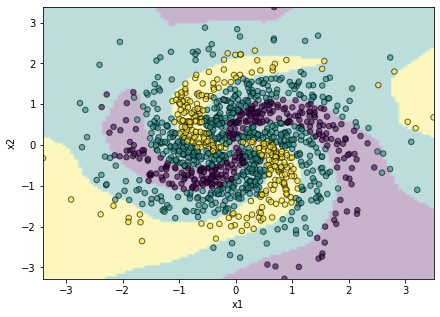

```python
# Predict and plot: take this code as black box
range1 = np.linspace(X[:,0].min(), X[:,0].max(), 100)
range2 = np.linspace(X[:,1].min(), X[:,1].max(), 100)
(xx1, xx2) = np.meshgrid(range1, range2)
Xgrid = np.column_stack((xx1.ravel(), xx2.ravel()))
phat = model.predict(Xgrid)
yhat = np.argmax(phat, axis=-1)
plt.figure(figsize=(7,5))
# plot the predicted values on grid as an image
plt.imshow(yhat.reshape((100,100)),
           alpha=0.3, extent=[xx1.min(), xx1.max(), xx2.min(), xx2.max()],
           origin='lower', aspect='auto')
# add the actual values
plt.scatter(X[:,0], X[:,1], c=y, s=30, alpha=0.6, edgecolor="k")
plt.xlabel("x1")
plt.ylabel("x2")
plt.show()
```